# Class 04: Multiple Comparisons

Hughes/Fisher

```r
library(tidyverse)
library(knitr)
```

**Recall the Tire Tread Comparison from Class 03:** A tire manufacturer is interested in investigating the handling properties for different tread patterns. Data were recorded on the stopping distances measured to the nearest foot for a standard sized car to come to a complete stop from a speed of 60 miles per hour. There are six measurements of the stopping distance for each of four different tread patterns labeled A, B, C and D. The same driver and car were used for all 24 measurements and, although not clear from the saved data file, the order of treatments were assigned at random.’

```r
Tire <- read.csv("http://users.miamioh.edu/hughesmr/sta363/TireData.csv")
tire.anova <- aov(StopDist ~ tire, data=Tire)
summary(tire.anova)
```

```
##             Df Sum Sq Mean Sq F value  Pr(>F)
## tire         3   5673  1891.0   5.328 0.00732 **
## Residuals   20   7099   354.9
## ---
## Signif. codes:  0 '***' 0.001 '**' 0.01 '*' 0.05 '.' 0.1 ' ' 1
```

The question we confront now is: **which tire tread patterns are different from each other?** The *F*-test only tells us that we can be confident that *some* difference exists, but it does not tell us which ones are different! To do so, we we need to perform a follow-up to the significant *F*-test.

## Follow-up Multiple Comparisons

We begin some follow-up procedures by revisiting the boxplots we made before running the ANOVA:

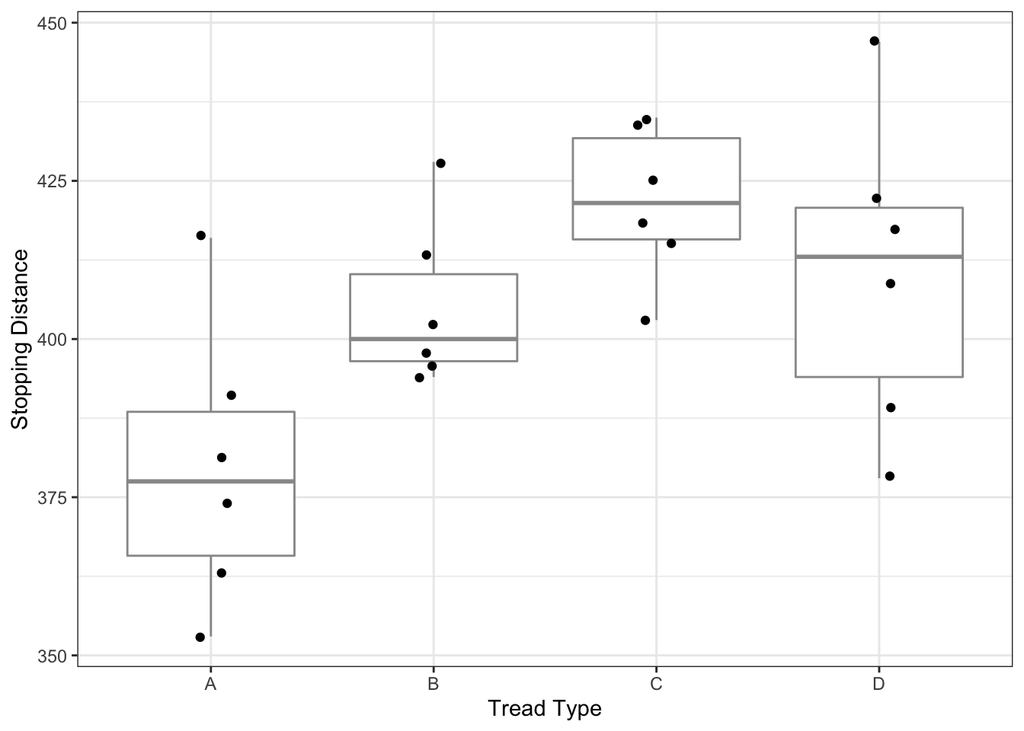

```r
ggplot(Tire) +
  geom_boxplot(aes(x=tire, y=StopDist), col="gray60" ) +
  geom_jitter(aes(x=tire, y=StopDist), width=0.1 ) +
  labs(x="Tread Type", y="Stopping Distance") +
  theme_bw()
```

By eyeball method, it sure looks like the stopping distance is shorter (smaller) in tire tread group $A$.

(BTW, what do you think `geom_jitter()` does?)

### How do we statistically test for differences?

It seems intuitive that we could perform a $t$-test comparing tread group $A$ to group $B$, and then tread group $A$ to $C$, $A$ to $D$, $B$ to $C$, $B$ to $D$ and $C$ to $D$. Note that one-way ANOVA essentially is comprised of 6 two-sample comparisons! That is, **it jointly makes all six comparisons at one time.**

**So why not just do six two-sample $t$-tests?** The answer relates to probability. First, recall from Intro Stats:

$$\textrm{significance level} = \alpha = P(\textrm{Type I error})$$

Further,

$$P(\textrm{No Type I error}) = 1 - P(\textrm{Type I error}) = 1 - \alpha$$

by the complements rule. Now, imagine I perform **two** statistical tests, each at significance level $\alpha$.

$$P(\textrm{No Type I errors in either test}) = P(\textrm{No Type I error in test 1 AND No Type I error in test 2})$$

The right hand side is comprised of two independent events (performing the first hypothesis test followed by a second). Thus,

$$P(\textrm{No Type I errors in either test}) = (1 - \alpha)\times(1-\alpha) = (1-\alpha)^2$$

Suppose $\alpha=0.05$, then $P(\textrm{No Type I errors in either test}) = 0.95^2 = 0.9025$, thus
$$P(\textrm{Type I error occurs}) = 1 - 0.9025 = 0.0975.$$

By the same rationale, if we performed **six** hypothesis tests, the probability of a Type I error occuring is
$$1 - (1 - \alpha)^6 = 1 - 0.95^6 = 0.2649$$

So, if we performed six two-sample *t*-tests, each at 5% significance, there is greater than a 25% chance we commit a Type I error somewhere in the complete analysis! This is generally considered unacceptable. Think about as to why.

### Multiple Comparisons

There are several methods available to adjust the overall significance level when performing multiple hypothesis tests (known as **multiple comparisons**):

#### Bonferoni Correction

One of the simplest methods is to just adjust the $\alpha$-level proportionally downward for each test you perform. This is typically known as a Bonferroni correction. Basically, if you are performing $m$ hypothesis tests, or building $m$ confidence intervals, perform each with significance level
$$\alpha^* = \frac{\alpha}{m},$$
or with corresponding confidence level $1-\alpha^* = 1-\alpha/m$. This is guaranteed to control the overall Type I error rate to be less than $\alpha$.

With six hypothesis tests, we would perform each at $0.05/6 = 0.008333$ which results in an overall error rate of $0.04897 < 0.05$.

The Bonferroni method is always available but generally not preferred when the number of comparisons is large, as it tends to be overly conservative in protecting against Type I errors.

#### Tukey HSD (“Honest Significant Differences”)

This method is attributed to John Tukey. (He has nothing to do with Thanksgiving.) The Tukey method controls the overall Type I error rate by adjusting the significance level each of the individual comparison but it does so in a more complex way than the naive Bonferroni approach above. The result can also be displayed as confidence intervals. It is implemented in the `emmeans` function.

```r
library(emmeans)                        # Load the package
tire.mc <- emmeans(tire.anova, "tire")  # Run emmeans on the factor "tire"
contrast(tire.mc, "pairwise")           # Perform pairwise comparisons
```

```
##  contrast estimate   SE df t.ratio p.value
##  A - B      -25.50 10.9 20 -2.344  0.1213
##  A - C      -42.00 10.9 20 -3.861  0.0050
##  A - D      -30.67 10.9 20 -2.819  0.0480
##  B - C      -16.50 10.9 20 -1.517  0.4465
##  B - D       -5.17 10.9 20 -0.475  0.9637
##  C - D       11.33 10.9 20  1.042  0.7274
##
## P value adjustment: tukey method for comparing a family of 4 estimates
```

Here, we see pairwise comparisons and the $p$-values of each comparison has been adjusted for the fact we are performing six multiple comparisons. We see that tread $A$ is different than $C$ and $D$; otherwise there is no difference in tread groups.

We can also calculate more informative confidence intervals of the comparisons.

```r
confint(contrast(tire.mc, "pairwise"))
```

```
##  contrast estimate   SE df lower.CL upper.CL
##  A - B      -25.50 10.9 20    -55.9    4.945
##  A - C      -42.00 10.9 20    -72.4  -11.555
##  A - D      -30.67 10.9 20    -61.1   -0.222
##  B - C      -16.50 10.9 20    -46.9   13.945
##  B - D       -5.17 10.9 20    -35.6   25.278
##  C - D       11.33 10.9 20    -19.1   41.778
##
## Confidence level used: 0.95
## Conf-level adjustment: tukey method for comparing a family of 4 estimates
```

From this output, we can conclude (with 95% confidence) that:

- tread $A$ has a mean stopping distance that is between 11.5 to 72.4 feet shorter than tread $C$
- tread $A$ has a mean stopping distance that is between 0.22 to 61.1 feet shorter than tread $D$
- no other tread types have significantly different mean stopping distances (all other CIs contain 0)

We can also plot the pairwise comparisons

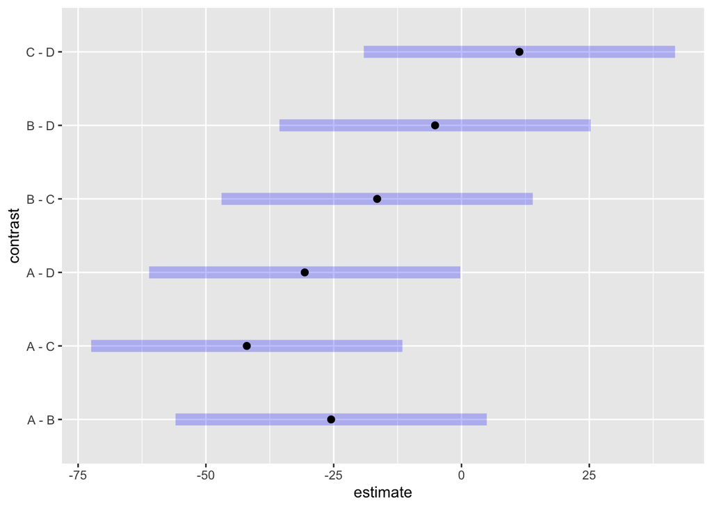

```r
plot(contrast(tire.mc, "pairwise"))
```

**Remember** when looking at the confidence intervals we are looking to see if **zero** is inside any given CI (this would indicate no significant difference).

#### Dunnett Multiple Comparisons

Another method for multiple comparison is known as Dunnett’s method. It works in a similar way (controlling the overall error rate) as Tukey. However, here one of the treatments (by default the first one listed) is considered a **control**, and the only comparisons considered are versus the control.

Suppose tire tread $D$ is the *control*. We simply need to tell `emmeans` that the reference factor level (`ref`) is the fourth one list; i.e., treatment $D$.

```r
contrast(tire.mc, "trt.vs.ctrl", ref=4)
```

```
##  contrast estimate   SE df t.ratio p.value
##  A - D      -30.67 10.9 20 -2.819  0.0287
##  B - D       -5.17 10.9 20 -0.475  0.9070
##  C - D       11.33 10.9 20  1.042  0.5970
##
## P value adjustment: dunnettx method for 3 tests
```

As before, we can calculate and plot the confidence intervals:

```r
confint(contrast(tire.mc, "trt.vs.ctrl", ref=4))
```

```
##  contrast estimate   SE df lower.CL upper.CL
##  A - D      -30.67 10.9 20    -58.5    -2.85
##  B - D       -5.17 10.9 20    -33.0    22.65
##  C - D       11.33 10.9 20    -16.5    39.15
##
## Confidence level used: 0.95
## Conf-level adjustment: dunnettx method for 3 estimates
```

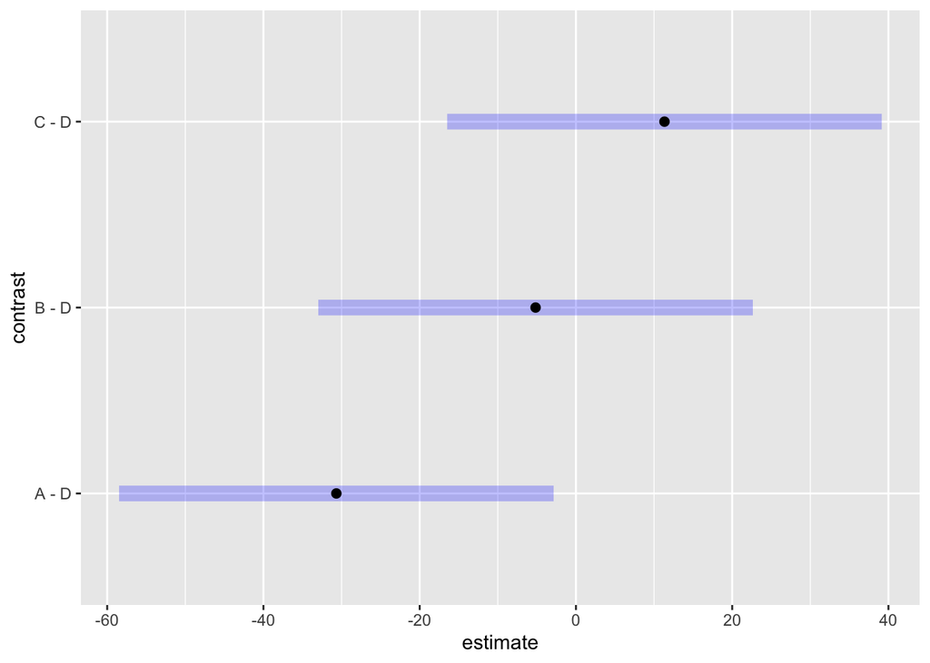

```r
plot(contrast(tire.mc, "trt.vs.ctrl", ref=4))
```